# Assignment 9

## Setup

```r
knitr::opts_chunk$set(echo = TRUE, comment = "#>", dpi = 300)

library(glue)
library(rstan)
library(tidybayes)
library(tidyverse)

for (f in list.files(here::here("src"), pattern = "R$", full.names = TRUE)) {
  source(f)
}

rstan_options(auto_write = TRUE)
options(mc.cores = 2)

theme_set(theme_classic() + theme(strip.background = element_blank()))

factory <- aaltobda::factory
set.seed(678)
```

**Assignment 9**

## Exercise 1. Decision analysis for the factory data

**Your task is to decide whether or not to buy a new (7th) machine for the company.** **The decision should be based on our best knowledge about the machines.**

**The following is known about the production process:**

- **The given data contains quality measurements of single products from the six machines that are ordered from the same seller. (columns: different machines, rows: measurements)**
- **Customers pay 200 euros for each product.** – **If the quality of the product is below 85, the product cannot be sold** – **All the products that have sufficient quality are sold.**
- **Raw-materials, the salary of the machine user and the usage cost of the machine for each product cost 106 euros in total.** – **Usage cost of the machine also involves all investment and repair costs divided by the number of products a machine can create. So there is no need to take the investment cost into account as a separate factor.**
- **The only thing the company owner cares about is money. Thus, as a utility function, use the profit of a new product from a machine.**

**a) For each of the six machines, compute and report the expected utility of one product of that machine.**

```r
PURCHASE_RPICE <- 200
MIN_QUALITY_TO_SELL <- 85
COST_TO_PRODUCE <- 106

utility <- function(draws) {
  purchased <- PURCHASE_RPICE * sum(draws >= MIN_QUALITY_TO_SELL)
  cost_to_produce <- -1 * COST_TO_PRODUCE * length(draws)
  u <- (purchased + cost_to_produce) / length(draws)
  return(u)
}

# Test case given in the assignment.
test_y_pred <- c(123.80, 85.23, 70.16, 80.57, 84.91)
test_res <- utility(draws = test_y_pred)
stop_if_not_close_to(test_res, -26)
```

Fit the hierarchical model and gather posterior predictions from each machine.

```r
hierarchical_model_code <- here::here(
  "models", "assignment07_factories_hierarchical.stan"
)

hierarchical_model_data <- list(
  y = factory,
  N = nrow(factory),
  J = ncol(factory)
)

hierarchical_model <- rstan::stan(
  hierarchical_model_code,
  data = hierarchical_model_data,
  verbose = FALSE,
  refresh = 0
)

print(hierarchical_model, pars = c("alpha", "tau", "mu", "sigma"))
```

```
#> Inference for Stan model: assignment07_factories_hierarchical.
#> 4 chains, each with iter=2000; warmup=1000; thin=1;
#> post-warmup draws per chain=1000, total post-warmup draws=4000.
#>
#>         mean se_mean   sd  2.5%    25%    50%    75%  97.5% n_eff
#> alpha  94.55    0.08 4.83 85.43  91.32  94.37  97.72 104.49  3501
#> tau    11.10    0.12 4.16  4.08   8.23  10.66  13.54  20.47  1212
#> mu[1]  81.53    0.16 6.34 69.02  77.32  81.42  85.70  94.91  1618
#> mu[2] 102.52    0.11 5.86 91.11  98.64 102.57 106.40 113.99  3076
#> mu[3]  89.82    0.09 5.55 79.06  86.07  89.76  93.49 100.91  4114
#> mu[4] 106.41    0.13 6.13 93.57 102.51 106.57 110.50 118.39  2285
#> mu[5]  91.29    0.08 5.37 80.40  87.93  91.28  94.86 102.05  4113
#> mu[6]  88.51    0.10 5.47 78.00  84.76  88.50  92.29  99.23  3143
#> sigma  14.27    0.04 2.08 10.87  12.79  14.02  15.50  18.81  2940
#>       Rhat
#> alpha    1
#> tau      1
#> mu[1]    1
#> mu[2]    1
#> mu[3]    1
#> mu[4]    1
#> mu[5]    1
#> mu[6]    1
#> sigma    1
#>
#> Samples were drawn using NUTS(diag_e) at Fri Dec  3 07:32:59 2021.
#> For each parameter, n_eff is a crude measure of effective sample size,
#> and Rhat is the potential scale reduction factor on split chains (at
#> convergence, Rhat=1).
```

Extract the posterior predictions for each machine and compare them to the observations.

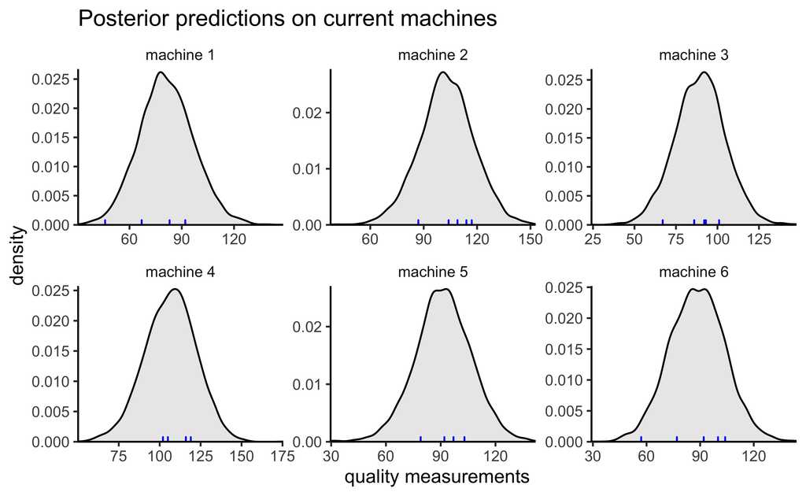

```r
factory_ypred <- rstan::extract(hierarchical_model, pars = "ypred")$ypred

tidy_factory_measure_matrix <- function(factory_mat) {
  as.data.frame(factory_mat) %>%
    set_names(glue("machine {seq(ncol(factory_mat))}")) %>%
    pivot_longer(-c(), names_to = "machine", values_to = "quality_measurement")
}

factory_long <- tidy_factory_measure_matrix(factory)

tidy_factory_measure_matrix(factory_ypred) %>%
  ggplot(aes(x = quality_measurement)) +
  facet_wrap(vars(machine), nrow = 2, scales = "free") +
  geom_density(fill = "black", alpha = 0.1) +
  geom_rug(data = factory_long, color = "blue") +
  scale_x_continuous(expand = expansion(c(0, 0))) +
  scale_y_continuous(expand = expansion(c(0, 0.02))) +
  labs(
    x = "quality measurements",
    y = "density",
    title = "Posterior predictions on current machines"
  )
```

Calculate the expected utility for each current machine.

```r
machine_utilities <- apply(factory_ypred, 2, utility)
tibble(
  machine = glue("machine {seq(length(machine_utilities))}"),
  expected_utility = machine_utilities
) %>%
  kableExtra::kbl()
```

| machine | expected_utility |
| --- | --- |
| machine 1 | -26.15 |
| machine 2 | 70.15 |
| machine 3 | 17.50 |
| machine 4 | 76.45 |
| machine 5 | 27.45 |
| machine 6 | 11.05 |

**b) Rank the machines based on the expected utilities.** **In other words order the machines from worst to best.** **Also briefly explain what the utility values tell about the quality of these machines.** **E.g. Tell which machines are profitable and which are not (if any).**

Based on their expected utility, the rankings of the machines from worst to best is: 1, 6, 3, 5, 2, 4. Machine 1 has a negative utility, indicating that it is expected to be unprofitable.

**c) Compute and report the expected utility of the products of a new (7th) machine.**

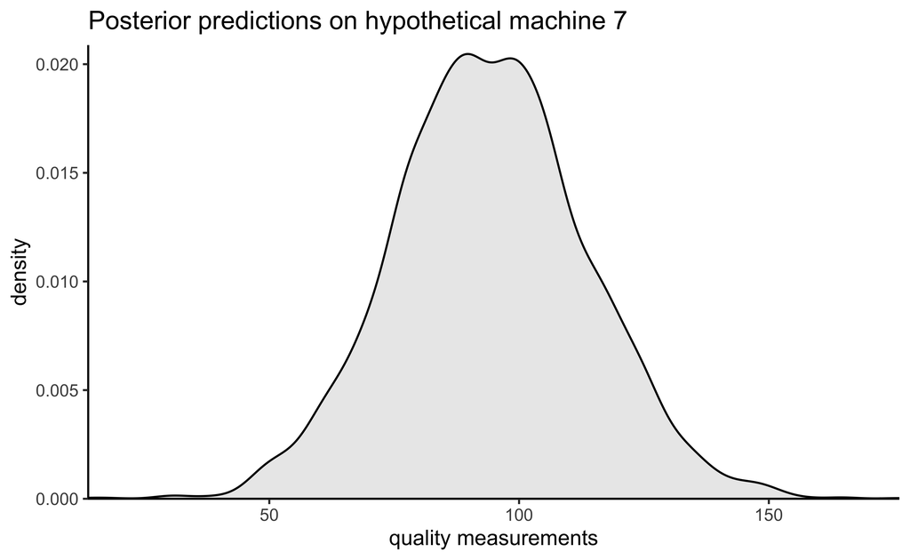

```r
machine7_pred <- rstan::extract(hierarchical_model, pars = "y7pred")$y7pred

ggplot(tibble(x = unlist(machine7_pred)), aes(x = x)) +
  geom_density(fill = "black", alpha = 0.1) +
  scale_x_continuous(expand = expansion(c(0, 0))) +
  scale_y_continuous(expand = expansion(c(0, 0.02))) +
  labs(
    x = "quality measurements",
    y = "density",
    title = "Posterior predictions on hypothetical machine 7"
  )
```

```r
# Expected utility from machine 7.
utility(machine7_pred)
```

```
#> [1] 30.7
```

The expected utility of hypothetical machine 7 is **30.7**.

**d) Based on your analysis, discuss briefly whether the company owner should buy a new (7th) machine.**

Based on this analysis, purchasing another machine would be expected to be profitable. It might be worth replacing machine 1 with this new machine.

**e) As usual, remember to include the source code for both Stan and R (or Python).**

The model is available here “assignment07_factories_hierarchical.stan”.

The only changes were made in the `generated quantities` block:

```
...
generated quantities {
  // Compute the predictive distribution for the sixth machine.
  real y6pred;  // Leave for compatibility with earlier assignments.
  vector[J] ypred;
  real mu7pred;
  real y7pred;
  vector[J] log_lik[N];

  y6pred = normal_rng(mu[6], sigma);
  for (j in 1:J) {
    ypred[j] = normal_rng(mu[j], sigma);
  }

  mu7pred = normal_rng(alpha, tau);
  y7pred = normal_rng(mu7pred, sigma);

  for (j in 1:J) {
    for (n in 1:N) {
      log_lik[n,j] = normal_lpdf(y[n,j] | mu[j], sigma);
    }
  }
}
```